# insecticides_growthcurver_1

Guy Mercer

02/10/2020

Machine Settings:

- Number of Cycles - 192
- Cycle Length - 300s
- Wavelength - 600nm
- Temperature - 30°C
- Shake - Before Each Cycle (272s)
- Shake Mode - Double Orbital
- Shake Frequency - 200rpm
- Total Well Volume - 200µl

I combined all the replicates using zsh to output a formatted, compiled csv file called formatted_compiled. I then edited the names of controls and blanks.

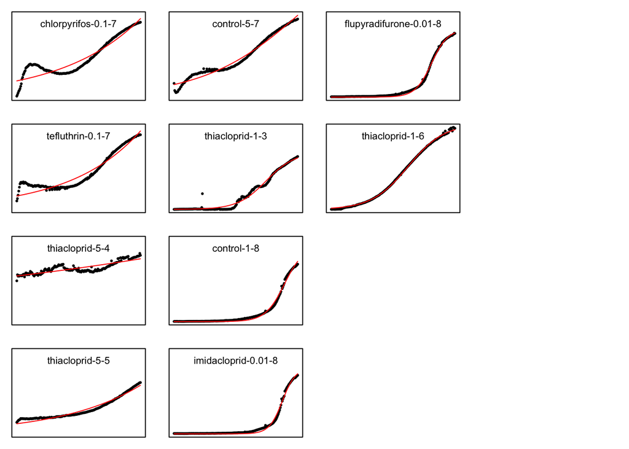

Sigma values represent the residual sum of squares from the fit of the logistic curve to the data, so larger values mean poorer fit to logistic model. Cypermethrin’s solubility issues artificially increased its starting OD readings, leading to a poor model fit.

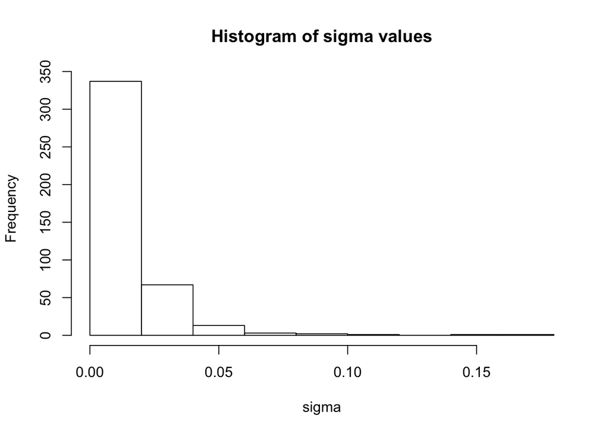

One additional method for identifying outlier parameters is to conduct a principal components analysis on the samples, which projects high dimensional data on lower dimensional space. Plotting the samples on the first two principal components (PC1 and PC2) can identify natural clusters within the growth curve data as well as outliers.

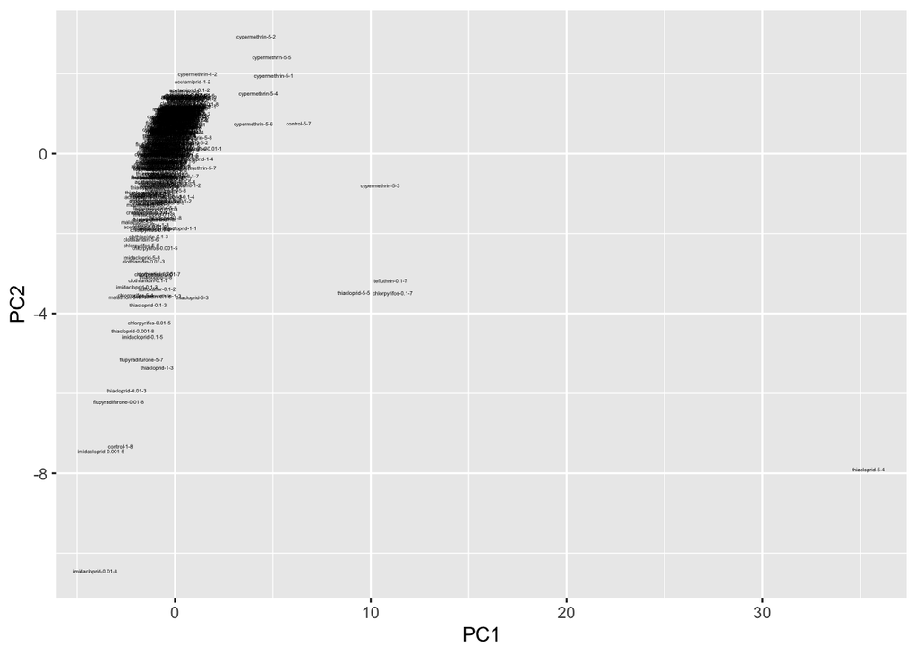

Need to remove outliers through a combination of PCA, sigma values and visual inspection of plots. Samples are removed if they fit the following three criteria: not bound by PCA y = -4 and x = 5, sigma > 0.05 and obvious error from visual inspection of plots. There were also some possible pipetting anomalies, described separately below.

Best option is to have three independent variables: concentration (continuous independent), insecticide (categorical independent) and day (categorical independent) and one dependent variable: AUC (continuous dependent). AUC = concentation + pesticide + day + (pesticide x concentration) (interaction). pesticide x concentration interaction is the interesting term. To do this the data has to be reformatted so there are columns with concentration, day and insecticide. At this point sulfoxaflor and cypermethrin were removed due to evaporation and solubility issues respectively.

Look at the variation by day. This variation was probably introduced by yeast cells not all being in mid-log phase growth, or variation in initial yeast cell number added to each well.

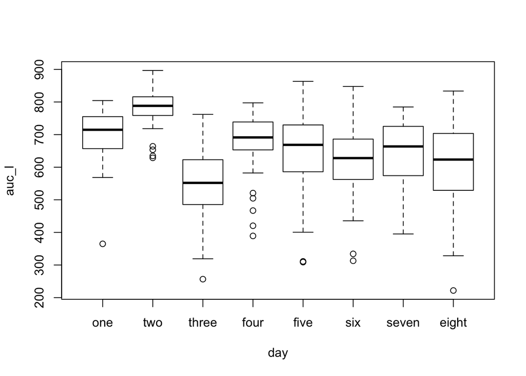

In my model I want to compare the interaction between no insecticide and concentration (controls) to the interaction between insecticides and concentration.

```
##
## Call:
## lm(formula = auc_l ~ insecticide + concentration + day + insecticide *
##     concentration, data = model_df_anomalies_removed)
##
## Residuals:
##      Min       1Q   Median       3Q      Max
## -292.447  -48.497    6.043   57.114  281.678
##
## Coefficients:
##                                           Estimate Std. Error t value Pr(>|t|)
## (Intercept)                               745.9913    22.0805  33.785  < 2e-16
## insecticideacetamiprid                     23.3126    25.0133   0.932 0.352024
## insecticidechlorpyrifos                   -76.0383    25.2336  -3.013 0.002787
## insecticideclothianidin                   -47.9678    25.0133  -1.918 0.056026
## insecticideflupyradifurone                 -0.4696    25.2332  -0.019 0.985164
## insecticideimidacloprid                   -70.7201    25.2332  -2.803 0.005373
## insecticidemalathion                       -8.5539    25.0133  -0.342 0.732591
## insecticidetefluthrin                     -47.3287    25.2336  -1.876 0.061603
## insecticidethiacloprid                    -58.3776    25.2975  -2.308 0.021647
## concentration                             -12.3669     8.1326  -1.521 0.129319
## daytwo                                     81.8712    19.7995   4.135 4.52e-05
## daythree                                 -156.8506    19.9145  -7.876 5.11e-14
## dayfour                                   -32.7823    19.9297  -1.645 0.100959
## dayfive                                   -71.6862    19.9297  -3.597 0.000372
## daysix                                    -84.8066    19.9145  -4.259 2.70e-05
## dayseven                                  -63.5850    20.1724  -3.152 0.001772
## dayeight                                  -92.9550    20.1590  -4.611 5.77e-06
## insecticideacetamiprid:concentration       12.6822    11.2074   1.132 0.258639
## insecticidechlorpyrifos:concentration      15.8326    11.2349   1.409 0.159721
## insecticideclothianidin:concentration      -1.7936    11.2074  -0.160 0.872949
## insecticideflupyradifurone:concentration    2.7186    11.2344   0.242 0.808943
## insecticideimidacloprid:concentration      10.8720    11.2344   0.968 0.333892
## insecticidemalathion:concentration         -7.6842    11.2074  -0.686 0.493427
## insecticidetefluthrin:concentration        20.1201    11.2349   1.791 0.074246
## insecticidethiacloprid:concentration      -34.0165    11.8808  -2.863 0.004467
##
## (Intercept)                              ***
## insecticideacetamiprid
## insecticidechlorpyrifos                  **
```

[output cut: 13 more lines]

```
## dayeight                                 ***
## insecticideacetamiprid:concentration
## insecticidechlorpyrifos:concentration
## insecticideclothianidin:concentration
## insecticideflupyradifurone:concentration
## insecticideimidacloprid:concentration
## insecticidemalathion:concentration
## insecticidetefluthrin:concentration      .
## insecticidethiacloprid:concentration     **
## ---
## Signif. codes:  0 '***' 0.001 '**' 0.01 '*' 0.05 '.' 0.1 ' ' 1
##
## Residual standard error: 93.92 on 325 degrees of freedom
## Multiple R-squared:  0.4581, Adjusted R-squared:  0.418
## F-statistic: 11.45 on 24 and 325 DF,  p-value: < 2.2e-16
```

Test assumptions of linear regression.

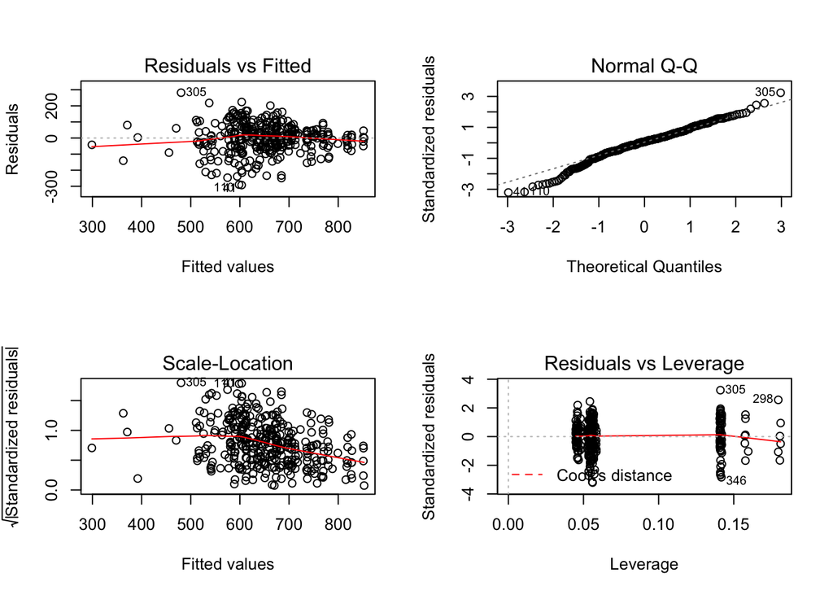

Residuals don’t have constant variance and shapiro test fails (not normally distributed). Look at the distribution of the dependent variable to visually identify potential transformation. Data is negatively skewed. A reflection and log transformation might make the dependent variable normally distributed.

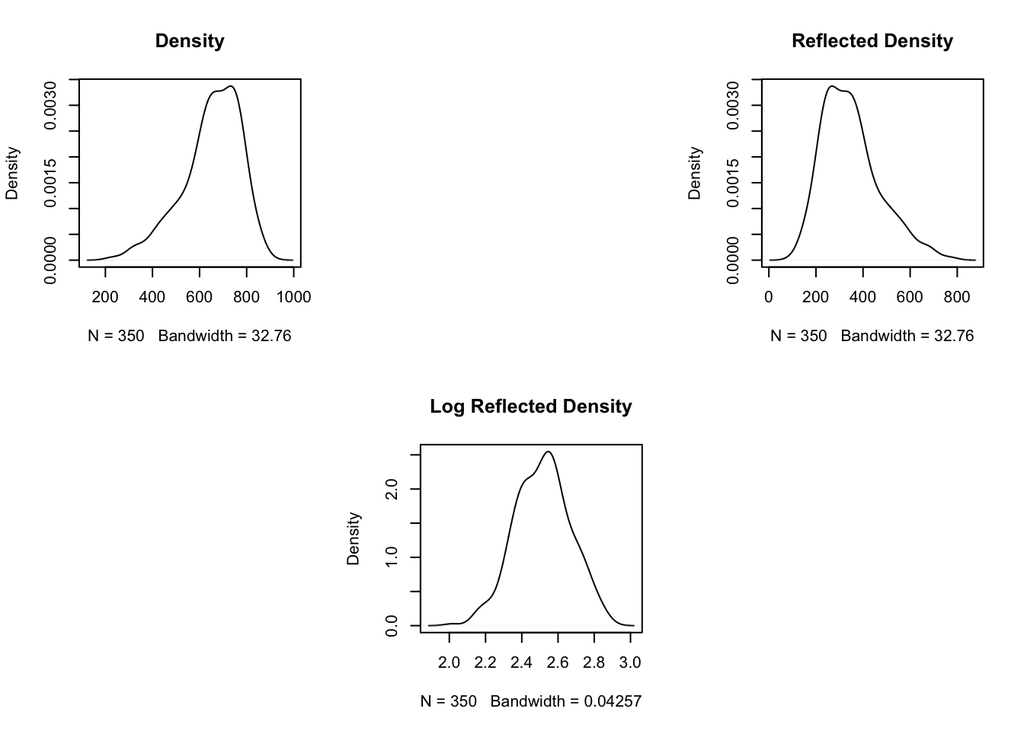

auc_l distribution looks closer to a normal distribution. Construct model again using this transformation and inspect residual plots etc.

```
##
## Call:
## lm(formula = auc_l ~ insecticide + concentration + day + insecticide *
##     concentration, data = transformed_data)
##
## Residuals:
##      Min       1Q   Median       3Q      Max
## -0.36628 -0.06867  0.00042  0.07056  0.28055
##
## Coefficients:
##                                            Estimate Std. Error t value Pr(>|t|)
## (Intercept)                               2.411e+00  2.663e-02  90.534  < 2e-16
## insecticideacetamiprid                   -4.319e-02  3.017e-02  -1.431  0.15326
## insecticidechlorpyrifos                   9.101e-02  3.044e-02   2.990  0.00300
## insecticideclothianidin                   5.743e-02  3.017e-02   1.903  0.05788
## insecticideflupyradifurone                3.207e-06  3.044e-02   0.000  0.99992
## insecticideimidacloprid                   8.644e-02  3.044e-02   2.840  0.00480
## insecticidemalathion                      1.759e-02  3.017e-02   0.583  0.56026
## insecticidetefluthrin                     7.466e-02  3.044e-02   2.453  0.01469
## insecticidethiacloprid                    6.650e-02  3.051e-02   2.179  0.03002
## concentration                             1.368e-02  9.810e-03   1.395  0.16412
## daytwo                                   -1.412e-01  2.388e-02  -5.911 8.58e-09
## daythree                                  1.832e-01  2.402e-02   7.627 2.69e-13
## dayfour                                   4.051e-02  2.404e-02   1.685  0.09293
## dayfive                                   7.703e-02  2.404e-02   3.204  0.00149
## daysix                                    1.029e-01  2.402e-02   4.285 2.41e-05
## dayseven                                  8.123e-02  2.433e-02   3.338  0.00094
## dayeight                                  1.082e-01  2.432e-02   4.449 1.19e-05
## insecticideacetamiprid:concentration     -1.408e-02  1.352e-02  -1.042  0.29829
## insecticidechlorpyrifos:concentration    -1.830e-02  1.355e-02  -1.350  0.17780
## insecticideclothianidin:concentration     6.698e-04  1.352e-02   0.050  0.96051
## insecticideflupyradifurone:concentration -2.180e-03  1.355e-02  -0.161  0.87227
## insecticideimidacloprid:concentration    -1.421e-02  1.355e-02  -1.049  0.29506
## insecticidemalathion:concentration        6.470e-03  1.352e-02   0.479  0.63252
## insecticidetefluthrin:concentration      -2.532e-02  1.355e-02  -1.868  0.06265
## insecticidethiacloprid:concentration      3.122e-02  1.433e-02   2.179  0.03009
##
## (Intercept)                              ***
## insecticideacetamiprid
## insecticidechlorpyrifos                  **
```

[output cut: 13 more lines]

```
## dayeight                                 ***
## insecticideacetamiprid:concentration
## insecticidechlorpyrifos:concentration
## insecticideclothianidin:concentration
## insecticideflupyradifurone:concentration
## insecticideimidacloprid:concentration
## insecticidemalathion:concentration
## insecticidetefluthrin:concentration      .
## insecticidethiacloprid:concentration     *
## ---
## Signif. codes:  0 '***' 0.001 '**' 0.01 '*' 0.05 '.' 0.1 ' ' 1
##
## Residual standard error: 0.1133 on 325 degrees of freedom
## Multiple R-squared:  0.487,  Adjusted R-squared:  0.4491
## F-statistic: 12.86 on 24 and 325 DF,  p-value: < 2.2e-16
```

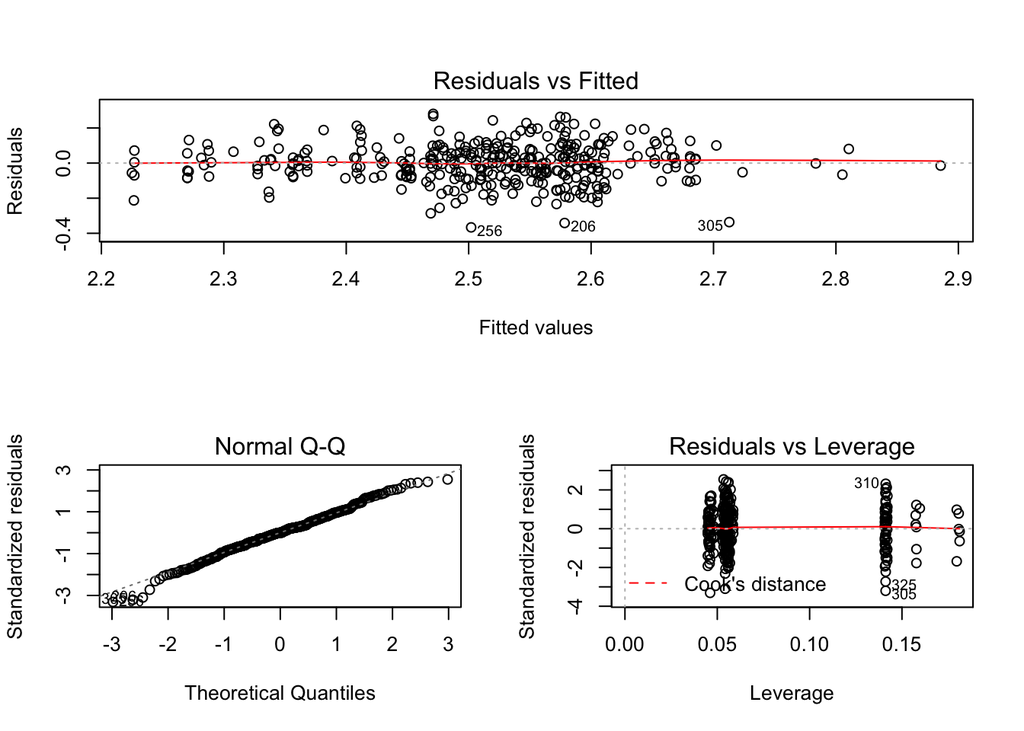

Interaction between thiacloprid and concentration is still significant. Investigate outliers.

The cook’s distance for each observation i measures the change in Ŷ (fitted Y) for all observations with and without the presence of observation i, so we know how much the observation i impacted the fitted values ([link](http://r-statistics.co/Outlier-Treatment-With-R.html)). How many of the observations above the cook cutoff are 5mM? 85%. The 5mM concentrations have a large influence over the fitted/predicted values. This is because Cook’s distance depends on both residual (y value) and leverage (x value). Looking at the Cook’s distance then is misleading because x was in experimental design.

The observations above aren’t anomalies. They are outliers and for this reason I can’t exclude them from the data. After a log transformation the model residuals reject the null hypothesis of a shapiro-wilks test (the data distribution follows a normal distribution).

I have to identify the distribution of my data. Fitdistrplus masks a part of tidyverse (I think). Once it’s loaded the PCA plot fails. If I unload the package it doesn’t solve the issue. I have to close R and reopen. This is why fitdistrplus isn’t loaded at the beginning like the other packages.

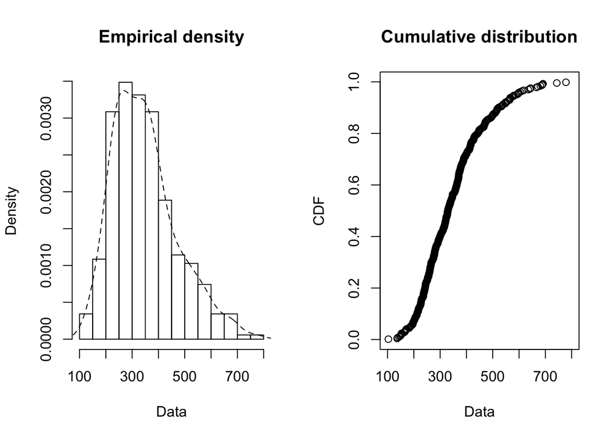

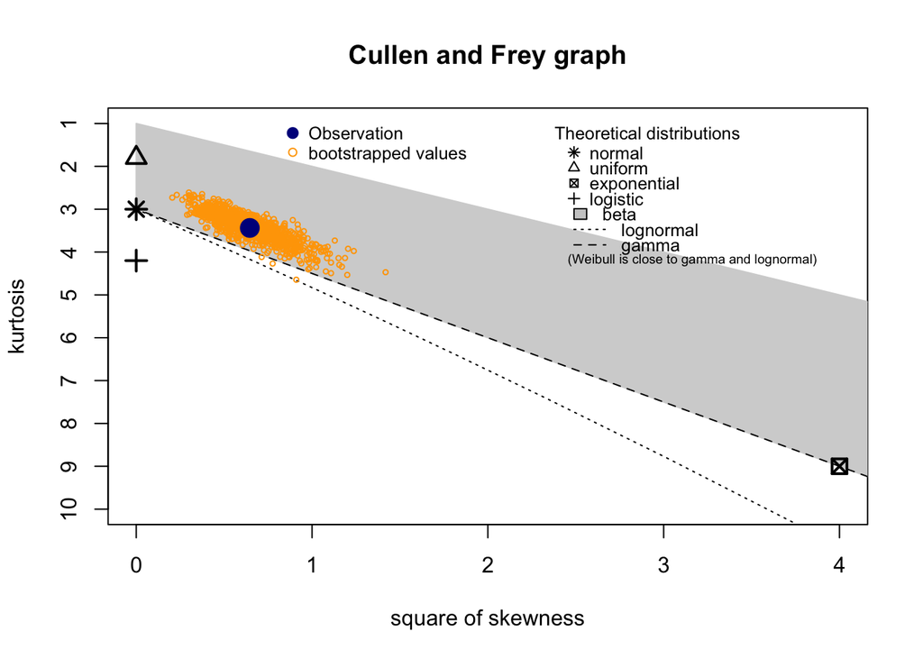

```
## summary statistics
## ------
## min:  103.2908   max:  778.1669
## median:  329.6693
## mean:  348.3902
## estimated sd:  123.1119
## estimated skewness:  0.803692
## estimated kurtosis:  3.437835
```

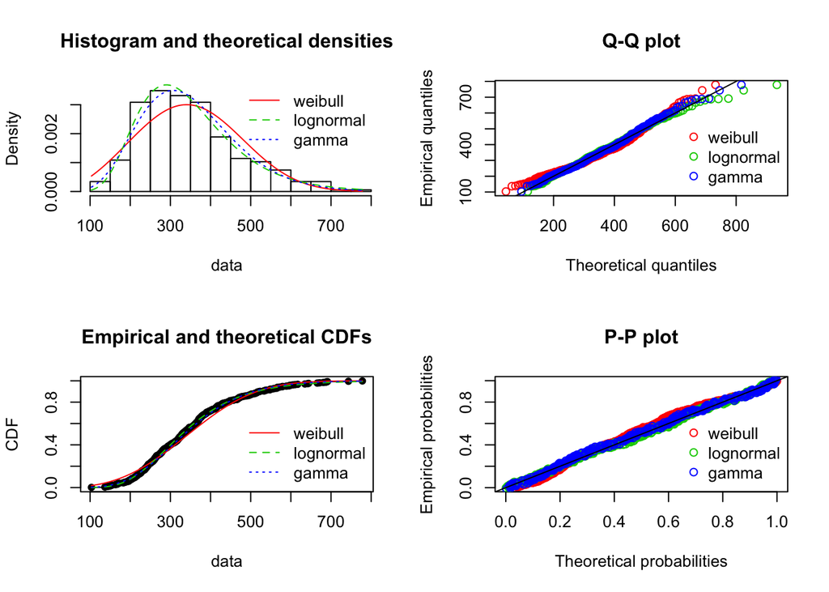

Contrary to the Shapiro Wilks Test, the AIC and other goodness of fit statistics suggest lognormal is the closest representation of the data distribution. This is supported by P-P plot, comparison of histogram with theoretical densities, comparison of empircal and theoretical CDF and partially by the Q-Q plot.

For a visualisation of mean AUC vs concentration for each insecticide (control part of insecticide)

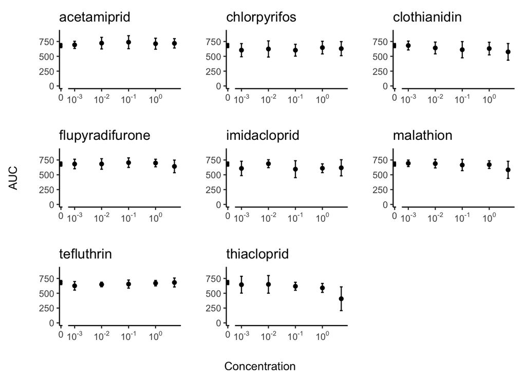

For a visualisation of mean AUC vs concentration for each insecticide (control (no insecticide) separate.

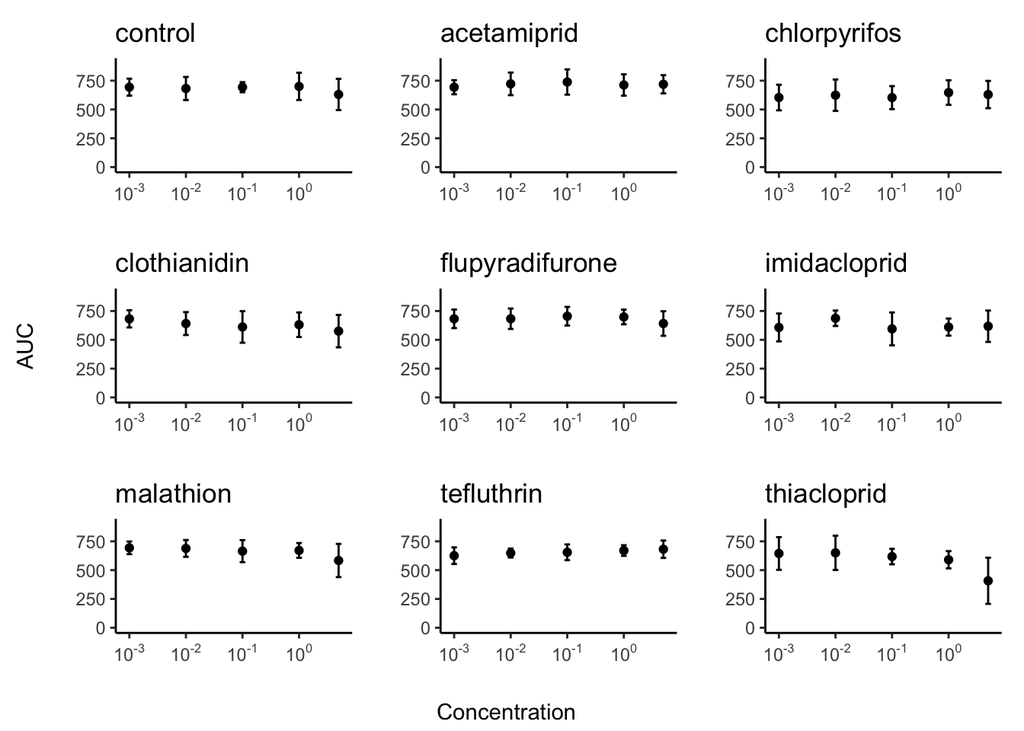

Plot individual replicates by day for each insecticide with a line connecting them.

Split by insecticide

Plot controls separate from insecticide. Get an idea of variation between insecticides.

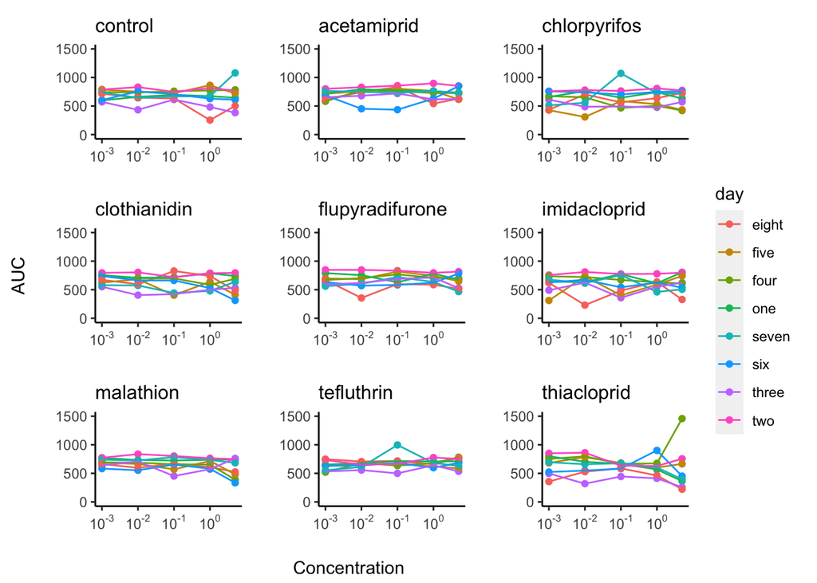

Does looking at growth rate (r) change any of the results?

```
##
## Call:
## lm(formula = r ~ insecticide + concentration + day + insecticide *
##     concentration, data = transformed_data_r)
##
## Residuals:
##        Min         1Q     Median         3Q        Max
## -4.614e-06 -9.770e-08  3.960e-08  2.063e-07  1.195e-06
##
## Coefficients:
##                                            Estimate Std. Error    t value
## (Intercept)                               3.000e+00  1.119e-07  2.681e+07
## insecticidechlorpyrifos                  -5.950e-08  1.265e-07 -4.700e-01
## insecticideclothianidin                  -8.361e-08  1.254e-07 -6.670e-01
## insecticidecontrol                        2.643e-08  1.261e-07  2.100e-01
## insecticideflupyradifurone                2.784e-08  1.266e-07  2.200e-01
## insecticideimidacloprid                  -2.963e-07  1.266e-07 -2.341e+00
## insecticidemalathion                      1.258e-07  1.254e-07  1.003e+00
## insecticidetefluthrin                     7.771e-08  1.265e-07  6.140e-01
## insecticidethiacloprid                   -1.058e-07  1.269e-07 -8.340e-01
## concentration                             1.524e-08  3.888e-08  3.920e-01
## dayfive                                  -7.839e-08  1.023e-07 -7.660e-01
## dayfour                                  -1.420e-07  1.023e-07 -1.388e+00
## dayone                                    1.407e-07  1.016e-07  1.385e+00
## dayseven                                  2.776e-08  1.035e-07  2.680e-01
## daysix                                   -4.195e-07  1.022e-07 -4.104e+00
## daythree                                 -1.316e-07  1.022e-07 -1.287e+00
## daytwo                                    1.284e-07  1.016e-07  1.263e+00
## insecticidechlorpyrifos:concentration    -3.579e-08  5.511e-08 -6.490e-01
## insecticideclothianidin:concentration     5.878e-08  5.499e-08  1.069e+00
## insecticidecontrol:concentration         -1.407e-08  5.651e-08 -2.490e-01
## insecticideflupyradifurone:concentration -1.004e-07  5.513e-08 -1.820e+00
## insecticideimidacloprid:concentration     2.204e-08  5.513e-08  4.000e-01
## insecticidemalathion:concentration       -9.020e-08  5.499e-08 -1.640e+00
## insecticidetefluthrin:concentration       2.911e-08  5.511e-08  5.280e-01
## insecticidethiacloprid:concentration      1.958e-07  5.845e-08  3.350e+00
##                                          Pr(>|t|)
## (Intercept)                               < 2e-16 ***
## insecticidechlorpyrifos                  0.638474
## insecticideclothianidin                  0.505466
```

[output cut: 13 more lines]

```
## daytwo                                   0.207565
## insecticidechlorpyrifos:concentration    0.516566
## insecticideclothianidin:concentration    0.285853
## insecticidecontrol:concentration         0.803530
## insecticideflupyradifurone:concentration 0.069612 .
## insecticideimidacloprid:concentration    0.689549
## insecticidemalathion:concentration       0.101869
## insecticidetefluthrin:concentration      0.597718
## insecticidethiacloprid:concentration     0.000904 ***
## ---
## Signif. codes:  0 '***' 0.001 '**' 0.01 '*' 0.05 '.' 0.1 ' ' 1
##
## Residual standard error: 4.735e-07 on 325 degrees of freedom
## Multiple R-squared:  0.2409, Adjusted R-squared:  0.1848
## F-statistic: 4.297 on 24 and 325 DF,  p-value: 5.529e-10
```

Interaction between thiacloprid and concentration is again significant. Less of the variation described by the model though.

Try and use a mixed model with day as a random effect. Difference between day explains 41% of the variance remaining after the variance explain by fixed effects.

Only fitted random-intercept model. A random-intercept model allows the intercept to vary for each level of the random effects, but keeps the slope constant among them. The intercept in this case is the initial growth on a certain day. So growth on some days may be larger or smaller to begin with. This assumes that the relationship between growth and insecticide concentration is the same on all days.

I could do a random-slope and random intercept model. This would allow both to intercept and slope to vary. So both baseline growth (intercept) and the relationship between growth and insecticide concentration (slope) can vary by day. However, I think it is unlikely for the relationship between growth and insecticide concentration to vary between days. Also, can’t get it to work.

Testing significance becomes complex for mixed models. This guide ([mixed models](http://bbolker.github.io/mixedmodels-misc/glmmFAQ.html#inference-and-confidence-intervals)) runs through some options. Models need to be nested (mine are [link](https://www.stat.ncsu.edu/people/bloomfield/courses/st430/slides/MandS-ch04-sec13-14.pdf)). Reference for LRT of fixed effects ([link](https://www.ssc.wisc.edu/sscc/pubs/MM/MM_TestEffects.html))

```
## Linear mixed model fit by REML ['lmerMod']
## Formula: auc_l ~ insecticide * concentration + (1 | day)
##    Data: transformed_data
##
## REML criterion at convergence: -402.2
##
## Scaled residuals:
##     Min      1Q  Median      3Q     Max
## -3.2273 -0.6063  0.0064  0.6113  2.4891
##
## Random effects:
##  Groups   Name        Variance Std.Dev.
##  day      (Intercept) 0.008923 0.09446
##  Residual             0.012834 0.11329
## Number of obs: 350, groups:  day, 8
##
## Fixed effects:
##                                            Estimate Std. Error t value
## (Intercept)                               2.468e+00  3.969e-02  62.169
## insecticideacetamiprid                   -4.315e-02  3.017e-02  -1.430
## insecticidechlorpyrifos                   9.102e-02  3.044e-02   2.991
## insecticideclothianidin                   5.747e-02  3.017e-02   1.905
## insecticideflupyradifurone               -1.662e-05  3.044e-02  -0.001
## insecticideimidacloprid                   8.642e-02  3.044e-02   2.839
## insecticidemalathion                      1.763e-02  3.017e-02   0.584
## insecticidetefluthrin                     7.468e-02  3.044e-02   2.454
## insecticidethiacloprid                    6.639e-02  3.051e-02   2.176
## concentration                             1.366e-02  9.809e-03   1.392
## insecticideacetamiprid:concentration     -1.406e-02  1.352e-02  -1.040
## insecticidechlorpyrifos:concentration    -1.827e-02  1.355e-02  -1.349
## insecticideclothianidin:concentration     6.909e-04  1.352e-02   0.051
## insecticideflupyradifurone:concentration -2.145e-03  1.355e-02  -0.158
## insecticideimidacloprid:concentration    -1.418e-02  1.355e-02  -1.046
## insecticidemalathion:concentration        6.492e-03  1.352e-02   0.480
## insecticidetefluthrin:concentration      -2.529e-02  1.355e-02  -1.866
## insecticidethiacloprid:concentration      3.124e-02  1.433e-02   2.180
```

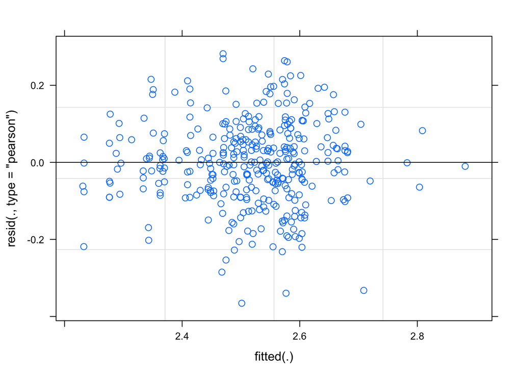

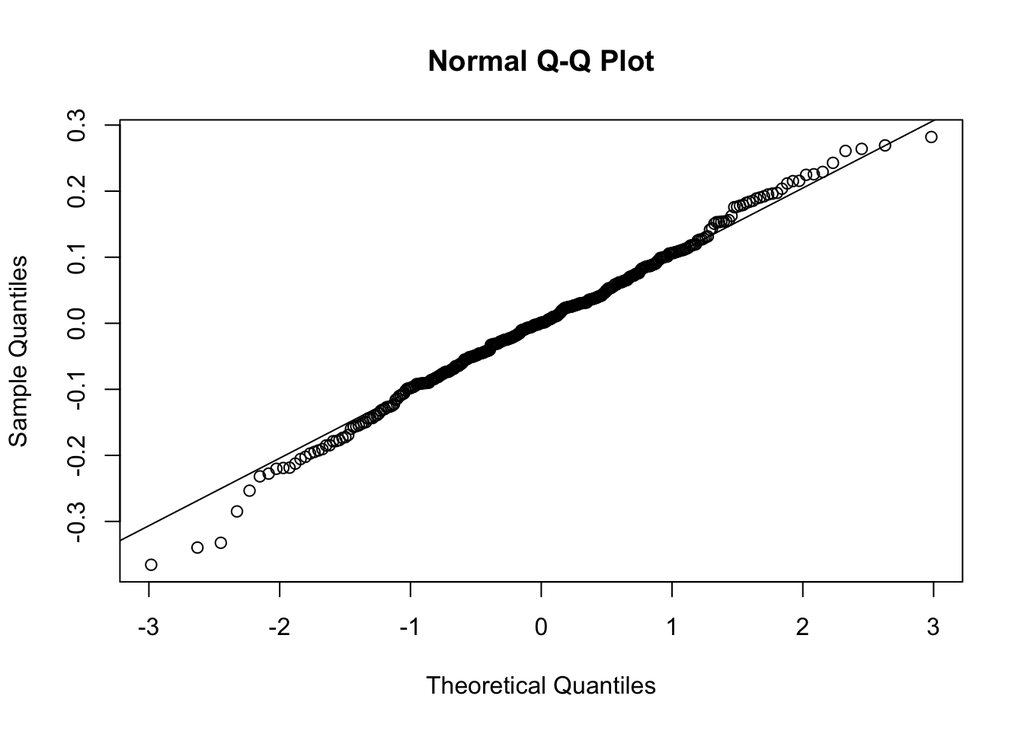

```
## Data: transformed_data
## Models:
## reduced.lmer: auc_l ~ 1 + (1 | day)
## full.lmer: auc_l ~ insecticide * concentration + (1 | day)
##              npar     AIC    BIC logLik deviance  Chisq Df Pr(>Chisq)
## reduced.lmer    3 -435.47 -423.9 220.74  -441.47
## full.lmer      20 -482.16 -405.0 261.08  -522.16 80.691 17  2.891e-10 ***
## ---
## Signif. codes:  0 '***' 0.001 '**' 0.01 '*' 0.05 '.' 0.1 ' ' 1
```

```
## Single term deletions
##
## Model:
## auc_l ~ insecticide * concentration + (1 | day)
##                           npar     AIC    LRT  Pr(Chi)
## <none>                         -482.16
## insecticide:concentration    8 -474.82 23.336 0.002959 **
## ---
## Signif. codes:  0 '***' 0.001 '**' 0.01 '*' 0.05 '.' 0.1 ' ' 1
```

Make model outputs presentable using sjPlot.